# Lab 6 - Model selection

Ilaria Prosdocimi

26 October 2021

We will analyze the dataset `prostate`:

```r
urlLocation <- "https://web.stanford.edu/~hastie/ElemStatLearn/datasets/prostate.data"
prostate <- read.table(urlLocation, header=TRUE)[,1:9]
## explanation of the data
## https://web.stanford.edu/~hastie/ElemStatLearn/datasets/prostate.info.txt
```

The variables in the dataset are

- lcavol: log cancer volume
- lweight: log prostate weight
- age: age of patient
- lbph: log of the amount of benign prostatic hyperplasia
- svi: seminal vesicle invasion (binary variable)
- lcp: log of capsular penetration
- gleason: Gleason score
- pgg45: percent of Gleason scores 4 or 5
- lpsa: log PSA score

We aim to select a model that to explain how `lpsa` is affected by other variables: this might be useful both for prediction purposes (i.e. predict the `lpsa` for a new patient) and for inference purposes (i.e. understanding which factors influence the `lpsa` values).

The relationship of `lpsa` against all the other variables in the dataset can be seen in the plot below:

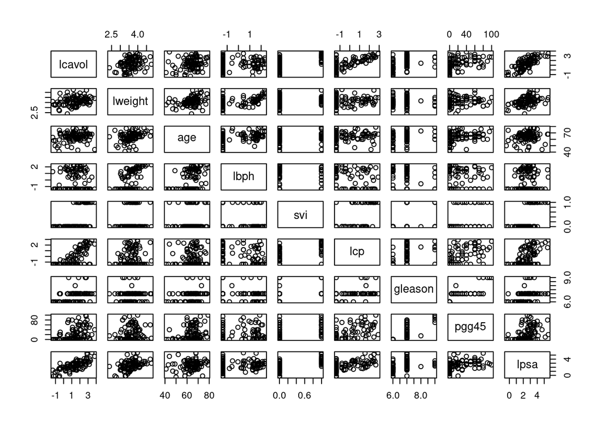

```r
plot(prostate)
```

The first two model we can think to fit are the simplest and most complex possible models, i.e. a model in which only the intercept is used and a model in which all the variables are included as predictors. To do that correctly we first transform the `svi` variable into a factor rather than a continuous variable:

```r
prostate$svi <- as.factor(prostate$svi)
fit_int_only <- lm(lpsa~1,data = prostate)
fit_all_vars <- lm(lpsa~.,data = prostate)
```

A first question is whether the more complex variable is “significant”:

```r
anova(fit_int_only, fit_all_vars)
```

```
## Analysis of Variance Table
##
## Model 1: lpsa ~ 1
## Model 2: lpsa ~ lcavol + lweight + age + lbph + svi + lcp + gleason +
##     pgg45
##   Res.Df     RSS Df Sum of Sq      F    Pr(>F)
## 1     96 127.918
## 2     88  43.058  8    84.859 21.679 < 2.2e-16 ***
## ---
## Signif. codes:  0 '***' 0.001 '**' 0.01 '*' 0.05 '.' 0.1 ' ' 1
```

It appears that including all variables explains a large proportion of the variability of the data. How can we find a model which is not too complex but complex enough to explain the a large proportion of the variability. We can use AIC to choose a model in which reductions in the negative log-likelihood are penalized by a function of the number of degrees of freedom for complex models. The AIC for the intercept-only model is 306.1116269. We could think of finding the best model with one explanatory variable:

```r
for(j in 1:(ncol(prostate)-1)) print(c(names(prostate)[j],AIC(lm(prostate$lpsa~prostate[,j]))))
```

```
## [1] "lcavol"           "232.908040520779"
## [1] "lweight"          "287.938884382005"
## [1] "age"             "305.28083171633"
## [1] "lbph"             "304.923660989906"
## [1] "svi"              "270.616301177566"
## [1] "lcp"              "273.348297964505"
## [1] "gleason"          "293.914939851134"
## [1] "pgg45"            "289.056791954584"
```

```r
## the lcavol variable is the one that reduces AIC the most
```

The next logical step would be to see whether adding any further variable decreases the AIC further. Rather than doing this manually we use the `step` function to perform a *forward* model selection, i.e. a model selection in which we start from a small model and add explanatory variables one by one as long as the AIC is reduced:

```r
fit_int_only <- lm(lpsa~1,data = prostate)
fit_all_vars <- lm(lpsa~.,data = prostate)
sel_forw <- step(object = fit_int_only, direction = "forward",
                 ## scope give the lower, i.e. simplest, and upper, most complex, limits
                 ## the "range" of models in which the algorithm will perform its search
     scope = list(lower=fit_int_only, upper = fit_all_vars))
```

```
## Start:  AIC=28.84
## lpsa ~ 1
##
##           Df Sum of Sq     RSS     AIC
## + lcavol   1    69.003  58.915 -44.366
## + svi      1    41.011  86.907  -6.658
## + lcp      1    38.528  89.389  -3.926
## + lweight  1    24.019 103.899  10.665
## + pgg45    1    22.814 105.103  11.783
## + gleason  1    17.416 110.502  16.641
## + lbph     1     4.136 123.782  27.650
## + age      1     3.679 124.239  28.007
## <none>                 127.918  28.838
##
## Step:  AIC=-44.37
## lpsa ~ lcavol
##
##           Df Sum of Sq    RSS     AIC
## + lweight  1    7.1726 51.742 -54.958
## + svi      1    5.2375 53.677 -51.397
## + lbph     1    3.2658 55.649 -47.898
## + pgg45    1    1.6980 57.217 -45.203
## <none>                 58.915 -44.366
## + lcp      1    0.6562 58.259 -43.452
## + gleason  1    0.4156 58.499 -43.053
## + age      1    0.0025 58.912 -42.370
##
## Step:  AIC=-54.96
## lpsa ~ lcavol + lweight
##
##           Df Sum of Sq    RSS     AIC
## + svi      1    5.1737 46.568 -63.177
## + pgg45    1    1.8158 49.926 -56.424
## <none>                 51.742 -54.958
## + lcp      1    0.8187 50.923 -54.506
## + gleason  1    0.7163 51.026 -54.311
## + age      1    0.6456 51.097 -54.176
## + lbph     1    0.4440 51.298 -53.794
##
## Step:  AIC=-63.18
```

[output cut: 13 more lines]

```
##           Df Sum of Sq    RSS     AIC
## + age      1   1.15879 44.437 -63.723
## <none>                 45.595 -63.226
## + pgg45    1   0.33173 45.264 -61.934
## + gleason  1   0.20691 45.389 -61.667
## + lcp      1   0.10115 45.494 -61.441
##
## Step:  AIC=-63.72
## lpsa ~ lcavol + lweight + svi + lbph + age
##
##           Df Sum of Sq    RSS     AIC
## <none>                 44.437 -63.723
## + pgg45    1   0.66071 43.776 -63.176
## + gleason  1   0.47674 43.960 -62.769
## + lcp      1   0.13040 44.306 -62.008
```

After 5 steps the algorithm stops and identifies the model using the following variables:

```r
names(sel_forw$coefficients)
```

```
## [1] "(Intercept)" "lcavol"      "lweight"     "svi1"        "lbph"
## [6] "age"
```

```r
-2*as.numeric(logLik(sel_forw)) + 2*(length(sel_forw$coefficients)+1)
```

```
## [1] 213.5514
```

```r
## or more simply
AIC(sel_forw)
```

```
## [1] 213.5514
```

```r
### step uses the MSS based definition
nrow(sel_forw$model)*log(mean(sel_forw$residuals^2)) + 2*(length(sel_forw$coefficients))
```

```
## [1] -63.72263
```

```r
## it's OK to use slightly different definition up or minus a constant, since what matters is the ranking
```

The other possible approach for model selection we can take is *backward* selection, in which from a more complex model we remove predictors one by one:

```r
sel_back <- step(object = fit_all_vars, direction = "backward",
     scope = list(lower=fit_int_only, upper = fit_all_vars))
```

```
## Start:  AIC=-60.78
## lpsa ~ lcavol + lweight + age + lbph + svi + lcp + gleason +
##     pgg45
##
##           Df Sum of Sq    RSS     AIC
## - gleason  1    0.0491 43.108 -62.668
## - pgg45    1    0.5102 43.569 -61.636
## - lcp      1    0.6814 43.740 -61.256
## <none>                 43.058 -60.779
## - lbph     1    1.3646 44.423 -59.753
## - age      1    1.7981 44.857 -58.810
## - lweight  1    4.6907 47.749 -52.749
## - svi      1    4.8803 47.939 -52.364
## - lcavol   1   20.1994 63.258 -25.467
##
## Step:  AIC=-62.67
## lpsa ~ lcavol + lweight + age + lbph + svi + lcp + pgg45
##
##           Df Sum of Sq    RSS     AIC
## - lcp      1    0.6684 43.776 -63.176
## <none>                 43.108 -62.668
## - pgg45    1    1.1987 44.306 -62.008
## - lbph     1    1.3844 44.492 -61.602
## - age      1    1.7579 44.865 -60.791
## - lweight  1    4.6429 47.751 -54.746
## - svi      1    4.8333 47.941 -54.360
## - lcavol   1   21.3191 64.427 -25.691
##
## Step:  AIC=-63.18
## lpsa ~ lcavol + lweight + age + lbph + svi + pgg45
##
##           Df Sum of Sq    RSS     AIC
## - pgg45    1    0.6607 44.437 -63.723
## <none>                 43.776 -63.176
## - lbph     1    1.3329 45.109 -62.266
## - age      1    1.4878 45.264 -61.934
## - svi      1    4.1766 47.953 -56.336
## - lweight  1    4.6553 48.431 -55.373
## - lcavol   1   22.7555 66.531 -24.572
##
## Step:  AIC=-63.72
## lpsa ~ lcavol + lweight + age + lbph + svi
##
##           Df Sum of Sq    RSS     AIC
## <none>                 44.437 -63.723
## - age      1    1.1588 45.595 -63.226
## - lbph     1    1.5087 45.945 -62.484
## - lweight  1    4.3140 48.751 -56.735
## - svi      1    5.8509 50.288 -53.724
## - lcavol   1   25.9427 70.379 -21.119
```

In this case we find the same model.

The last possible approach to follow is *stepwise* model selection in which the algorithm at each time tests whether adding or removing any predictor improves the goodness of fit of the model. The algorithm can be implemented starting from a simple or a complex model:

```r
sel_both <- step(object = fit_int_only, direction = "both",
     scope = list(lower=fit_int_only, upper = fit_all_vars))
```

```
## Start:  AIC=28.84
## lpsa ~ 1
##
##           Df Sum of Sq     RSS     AIC
## + lcavol   1    69.003  58.915 -44.366
## + svi      1    41.011  86.907  -6.658
## + lcp      1    38.528  89.389  -3.926
## + lweight  1    24.019 103.899  10.665
## + pgg45    1    22.814 105.103  11.783
## + gleason  1    17.416 110.502  16.641
## + lbph     1     4.136 123.782  27.650
## + age      1     3.679 124.239  28.007
## <none>                 127.918  28.838
##
## Step:  AIC=-44.37
## lpsa ~ lcavol
##
##           Df Sum of Sq     RSS     AIC
## + lweight  1     7.173  51.742 -54.958
## + svi      1     5.237  53.677 -51.397
## + lbph     1     3.266  55.649 -47.898
## + pgg45    1     1.698  57.217 -45.203
## <none>                  58.915 -44.366
## + lcp      1     0.656  58.259 -43.452
## + gleason  1     0.416  58.499 -43.053
## + age      1     0.003  58.912 -42.370
## - lcavol   1    69.003 127.918  28.838
##
## Step:  AIC=-54.96
## lpsa ~ lcavol + lweight
##
##           Df Sum of Sq     RSS     AIC
## + svi      1     5.174  46.568 -63.177
## + pgg45    1     1.816  49.926 -56.424
## <none>                  51.742 -54.958
## + lcp      1     0.819  50.923 -54.506
## + gleason  1     0.716  51.026 -54.311
## + age      1     0.646  51.097 -54.176
## + lbph     1     0.444  51.298 -53.794
## - lweight  1     7.173  58.915 -44.366
```

[output cut: 28 more lines]

```
## - lcavol   1   24.9384 70.534 -22.906
##
## Step:  AIC=-63.72
## lpsa ~ lcavol + lweight + svi + lbph + age
##
##           Df Sum of Sq    RSS     AIC
## <none>                 44.437 -63.723
## - age      1    1.1588 45.595 -63.226
## + pgg45    1    0.6607 43.776 -63.176
## + gleason  1    0.4767 43.960 -62.769
## - lbph     1    1.5087 45.945 -62.484
## + lcp      1    0.1304 44.306 -62.008
## - lweight  1    4.3140 48.751 -56.735
## - svi      1    5.8509 50.288 -53.724
## - lcavol   1   25.9427 70.379 -21.119
```

```r
sel_both_bis <- step(object = fit_all_vars, direction = "both",
     scope = list(lower=fit_int_only, upper = fit_all_vars))
```

```
## Start:  AIC=-60.78
## lpsa ~ lcavol + lweight + age + lbph + svi + lcp + gleason +
##     pgg45
##
##           Df Sum of Sq    RSS     AIC
## - gleason  1    0.0491 43.108 -62.668
## - pgg45    1    0.5102 43.569 -61.636
## - lcp      1    0.6814 43.740 -61.256
## <none>                 43.058 -60.779
## - lbph     1    1.3646 44.423 -59.753
## - age      1    1.7981 44.857 -58.810
## - lweight  1    4.6907 47.749 -52.749
## - svi      1    4.8803 47.939 -52.364
## - lcavol   1   20.1994 63.258 -25.467
##
## Step:  AIC=-62.67
## lpsa ~ lcavol + lweight + age + lbph + svi + lcp + pgg45
##
##           Df Sum of Sq    RSS     AIC
## - lcp      1    0.6684 43.776 -63.176
## <none>                 43.108 -62.668
## - pgg45    1    1.1987 44.306 -62.008
## - lbph     1    1.3844 44.492 -61.602
## - age      1    1.7579 44.865 -60.791
## + gleason  1    0.0491 43.058 -60.779
## - lweight  1    4.6429 47.751 -54.746
## - svi      1    4.8333 47.941 -54.360
## - lcavol   1   21.3191 64.427 -25.691
##
## Step:  AIC=-63.18
## lpsa ~ lcavol + lweight + age + lbph + svi + pgg45
##
##           Df Sum of Sq    RSS     AIC
## - pgg45    1    0.6607 44.437 -63.723
## <none>                 43.776 -63.176
## + lcp      1    0.6684 43.108 -62.668
## - lbph     1    1.3329 45.109 -62.266
## - age      1    1.4878 45.264 -61.934
## + gleason  1    0.0362 43.740 -61.256
## - svi      1    4.1766 47.953 -56.336
## - lweight  1    4.6553 48.431 -55.373
## - lcavol   1   22.7555 66.531 -24.572
##
## Step:  AIC=-63.72
## lpsa ~ lcavol + lweight + age + lbph + svi
##
##           Df Sum of Sq    RSS     AIC
## <none>                 44.437 -63.723
## - age      1    1.1588 45.595 -63.226
## + pgg45    1    0.6607 43.776 -63.176
## + gleason  1    0.4767 43.960 -62.769
## - lbph     1    1.5087 45.945 -62.484
## + lcp      1    0.1304 44.306 -62.008
## - lweight  1    4.3140 48.751 -56.735
## - svi      1    5.8509 50.288 -53.724
## - lcavol   1   25.9427 70.379 -21.119
```

```r
### regardless of where we start we find the same model
identical(sort(names(sel_both$coefficients)),
          sort(names(sel_both_bis$coefficients)))
```

```
## [1] TRUE
```

In this particular case all three selection methods indicate that the same variables should be included in the model:

```r
identical(sort(names(sel_back$coefficients)),
          sort(names(sel_forw$coefficients)))
```

```
## [1] TRUE
```

```r
identical(sort(names(sel_back$coefficients)),
          sort(names(sel_both_bis$coefficients)))
```

```
## [1] TRUE
```

Let’s have a look at how well the model fits the observed data:

```r
summary(sel_back)
```

```
##
## Call:
## lm(formula = lpsa ~ lcavol + lweight + age + lbph + svi, data = prostate)
##
## Residuals:
##      Min       1Q   Median       3Q      Max
## -1.86717 -0.37725  0.01257  0.40252  1.44544
##
## Coefficients:
##             Estimate Std. Error t value Pr(>|t|)
## (Intercept)  0.49473    0.87652   0.564  0.57385
## lcavol       0.54400    0.07463   7.289 1.11e-10 ***
## lweight      0.58821    0.19790   2.972  0.00378 **
## age         -0.01644    0.01068  -1.540  0.12692
## lbph         0.10122    0.05759   1.758  0.08215 .
## svi1         0.71490    0.20653   3.461  0.00082 ***
## ---
## Signif. codes:  0 '***' 0.001 '**' 0.01 '*' 0.05 '.' 0.1 ' ' 1
##
## Residual standard error: 0.6988 on 91 degrees of freedom
## Multiple R-squared:  0.6526, Adjusted R-squared:  0.6335
## F-statistic: 34.19 on 5 and 91 DF,  p-value: < 2.2e-16
```

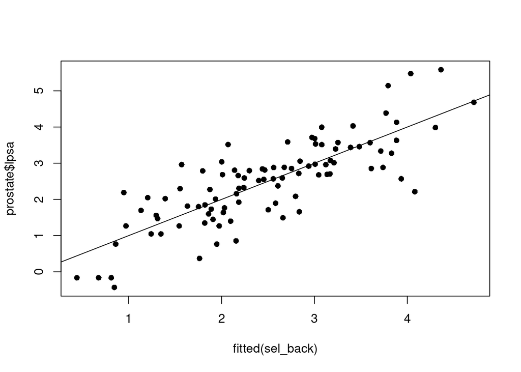

```r
plot(fitted(sel_back),prostate$lpsa, pch=16)
abline(0,1) ## not bad
```

We can see that the model is significant against the null model and seems to retrieve a decent for for the original data. On the other hand when we compare the chosen model with the most complex model possible we see that the inclusion of additional variables does not result in a significant difference in the RSS:

```r
anova(sel_back, fit_all_vars)
```

```
## Analysis of Variance Table
##
## Model 1: lpsa ~ lcavol + lweight + age + lbph + svi
## Model 2: lpsa ~ lcavol + lweight + age + lbph + svi + lcp + gleason +
##     pgg45
##   Res.Df    RSS Df Sum of Sq      F Pr(>F)
## 1     91 44.437
## 2     88 43.058  3    1.3783 0.9389 0.4254
```

Till now we have used AIC as the criterion to choose which variables to include. An alternative is to use the BIC, in which more complex models are penalized more for a dataset with large $n$ since its form is:
$$BIC(M) = - logLik(M) + \log(n) * p(M).$$

Let’s compare AIC and BIC values for the two most extreme models:

```r
AIC(fit_all_vars); AIC(fit_int_only)
```

```
## [1] 216.4952
```

```
## [1] 306.1116
```

```r
BIC(fit_all_vars); BIC(fit_int_only)
```

```
## [1] 242.2423
```

```
## [1] 311.261
```

```r
## alternatively AIC(fit_int_only, k=log(nrow(prostate)))
```

We can still use the `step` function to identify models which minimize the BIC:

```r
sel_bic_back <- step(object = fit_all_vars, direction = "backward",
     scope = list(lower=fit_int_only, upper = fit_all_vars),k=log(nrow(prostate)))
```

```
## Start:  AIC=-37.61
## lpsa ~ lcavol + lweight + age + lbph + svi + lcp + gleason +
##     pgg45
##
##           Df Sum of Sq    RSS     AIC
## - gleason  1    0.0491 43.108 -42.071
## - pgg45    1    0.5102 43.569 -41.039
## - lcp      1    0.6814 43.740 -40.658
## - lbph     1    1.3646 44.423 -39.155
## - age      1    1.7981 44.857 -38.213
## <none>                 43.058 -37.606
## - lweight  1    4.6907 47.749 -32.151
## - svi      1    4.8803 47.939 -31.767
## - lcavol   1   20.1994 63.258  -4.869
##
## Step:  AIC=-42.07
## lpsa ~ lcavol + lweight + age + lbph + svi + lcp + pgg45
##
##           Df Sum of Sq    RSS     AIC
## - lcp      1    0.6684 43.776 -45.153
## - pgg45    1    1.1987 44.306 -43.985
## - lbph     1    1.3844 44.492 -43.579
## - age      1    1.7579 44.865 -42.768
## <none>                 43.108 -42.071
## - lweight  1    4.6429 47.751 -36.723
## - svi      1    4.8333 47.941 -36.337
## - lcavol   1   21.3191 64.427  -7.668
##
## Step:  AIC=-45.15
## lpsa ~ lcavol + lweight + age + lbph + svi + pgg45
##
##           Df Sum of Sq    RSS     AIC
## - pgg45    1    0.6607 44.437 -48.274
## - lbph     1    1.3329 45.109 -46.818
## - age      1    1.4878 45.264 -46.486
## <none>                 43.776 -45.153
## - svi      1    4.1766 47.953 -40.888
## - lweight  1    4.6553 48.431 -39.924
## - lcavol   1   22.7555 66.531  -9.124
##
```

[output cut: 14 more lines]

```
##           Df Sum of Sq    RSS     AIC
## - lbph     1    0.9730 46.568 -52.879
## <none>                 45.595 -50.352
## - lweight  1    3.6907 49.286 -47.377
## - svi      1    5.7027 51.298 -43.496
## - lcavol   1   24.9384 70.534 -12.607
##
## Step:  AIC=-52.88
## lpsa ~ lcavol + lweight + svi
##
##           Df Sum of Sq    RSS     AIC
## <none>                 46.568 -52.879
## - svi      1    5.1737 51.742 -47.234
## - lweight  1    7.1089 53.677 -43.673
## - lcavol   1   24.7058 71.274 -16.169
```

```r
sel_bic_forw <- step(object = fit_int_only, direction = "forward",
     scope = list(lower=fit_int_only, upper = fit_all_vars),k=log(nrow(prostate)))
```

```
## Start:  AIC=31.41
## lpsa ~ 1
##
##           Df Sum of Sq     RSS     AIC
## + lcavol   1    69.003  58.915 -39.217
## + svi      1    41.011  86.907  -1.508
## + lcp      1    38.528  89.389   1.224
## + lweight  1    24.019 103.899  15.814
## + pgg45    1    22.814 105.103  16.932
## + gleason  1    17.416 110.502  21.790
## <none>                 127.918  31.412
## + lbph     1     4.136 123.782  32.799
## + age      1     3.679 124.239  33.156
##
## Step:  AIC=-39.22
## lpsa ~ lcavol
##
##           Df Sum of Sq    RSS     AIC
## + lweight  1    7.1726 51.742 -47.234
## + svi      1    5.2375 53.677 -43.673
## + lbph     1    3.2658 55.649 -40.174
## <none>                 58.915 -39.217
## + pgg45    1    1.6980 57.217 -37.479
## + lcp      1    0.6562 58.259 -35.728
## + gleason  1    0.4156 58.499 -35.329
## + age      1    0.0025 58.912 -34.646
##
## Step:  AIC=-47.23
## lpsa ~ lcavol + lweight
##
##           Df Sum of Sq    RSS     AIC
## + svi      1    5.1737 46.568 -52.879
## <none>                 51.742 -47.234
## + pgg45    1    1.8158 49.926 -46.125
## + lcp      1    0.8187 50.923 -44.207
## + gleason  1    0.7163 51.026 -44.012
## + age      1    0.6456 51.097 -43.878
## + lbph     1    0.4440 51.298 -43.496
##
## Step:  AIC=-52.88
## lpsa ~ lcavol + lweight + svi
##
##           Df Sum of Sq    RSS     AIC
## <none>                 46.568 -52.879
## + lbph     1   0.97296 45.595 -50.352
## + age      1   0.62301 45.945 -49.610
## + pgg45    1   0.50069 46.068 -49.352
## + gleason  1   0.34449 46.224 -49.024
## + lcp      1   0.06937 46.499 -48.448
```

```r
sel_bic_both <- step(object = fit_all_vars, direction = "both",
     scope = list(lower=fit_int_only, upper = fit_all_vars),k=log(nrow(prostate)))
```

```
## Start:  AIC=-37.61
## lpsa ~ lcavol + lweight + age + lbph + svi + lcp + gleason +
##     pgg45
##
##           Df Sum of Sq    RSS     AIC
## - gleason  1    0.0491 43.108 -42.071
## - pgg45    1    0.5102 43.569 -41.039
## - lcp      1    0.6814 43.740 -40.658
## - lbph     1    1.3646 44.423 -39.155
## - age      1    1.7981 44.857 -38.213
## <none>                 43.058 -37.606
## - lweight  1    4.6907 47.749 -32.151
## - svi      1    4.8803 47.939 -31.767
## - lcavol   1   20.1994 63.258  -4.869
##
## Step:  AIC=-42.07
## lpsa ~ lcavol + lweight + age + lbph + svi + lcp + pgg45
##
##           Df Sum of Sq    RSS     AIC
## - lcp      1    0.6684 43.776 -45.153
## - pgg45    1    1.1987 44.306 -43.985
## - lbph     1    1.3844 44.492 -43.579
## - age      1    1.7579 44.865 -42.768
## <none>                 43.108 -42.071
## + gleason  1    0.0491 43.058 -37.606
## - lweight  1    4.6429 47.751 -36.723
## - svi      1    4.8333 47.941 -36.337
## - lcavol   1   21.3191 64.427  -7.668
##
## Step:  AIC=-45.15
## lpsa ~ lcavol + lweight + age + lbph + svi + pgg45
##
##           Df Sum of Sq    RSS     AIC
## - pgg45    1    0.6607 44.437 -48.274
## - lbph     1    1.3329 45.109 -46.818
## - age      1    1.4878 45.264 -46.486
## <none>                 43.776 -45.153
## + lcp      1    0.6684 43.108 -42.071
## - svi      1    4.1766 47.953 -40.888
## + gleason  1    0.0362 43.740 -40.658
```

[output cut: 29 more lines]

```
## - lcavol   1   24.9384 70.534 -12.607
##
## Step:  AIC=-52.88
## lpsa ~ lcavol + lweight + svi
##
##           Df Sum of Sq    RSS     AIC
## <none>                 46.568 -52.879
## + lbph     1    0.9730 45.595 -50.352
## + age      1    0.6230 45.945 -49.610
## + pgg45    1    0.5007 46.068 -49.352
## + gleason  1    0.3445 46.224 -49.024
## + lcp      1    0.0694 46.499 -48.448
## - svi      1    5.1737 51.742 -47.234
## - lweight  1    7.1089 53.677 -43.673
## - lcavol   1   24.7058 71.274 -16.169
```

Finally we can use the *exhaustive* search method, in which we compare in an exhaustive way all possible models which can be fitted to the data. The algorithm is implemented in the `regsubsets` function in the package `leaps`:

```r
if(!any(rownames(installed.packages()) == "leaps")) install.packages("leaps")
library(leaps)
all_mod <-summary(regsubsets(lpsa ~ ., data = prostate))
all_mod
```

```
## Subset selection object
## Call: regsubsets.formula(lpsa ~ ., data = prostate)
## 8 Variables  (and intercept)
##         Forced in Forced out
## lcavol      FALSE      FALSE
## lweight     FALSE      FALSE
## age         FALSE      FALSE
## lbph        FALSE      FALSE
## svi1        FALSE      FALSE
## lcp         FALSE      FALSE
## gleason     FALSE      FALSE
## pgg45       FALSE      FALSE
## 1 subsets of each size up to 8
## Selection Algorithm: exhaustive
##          lcavol lweight age lbph svi1 lcp gleason pgg45
## 1  ( 1 ) "*"    " "     " " " "  " "  " " " "     " "
## 2  ( 1 ) "*"    "*"     " " " "  " "  " " " "     " "
## 3  ( 1 ) "*"    "*"     " " " "  "*"  " " " "     " "
## 4  ( 1 ) "*"    "*"     " " "*"  "*"  " " " "     " "
## 5  ( 1 ) "*"    "*"     "*" "*"  "*"  " " " "     " "
## 6  ( 1 ) "*"    "*"     "*" "*"  "*"  " " " "     "*"
## 7  ( 1 ) "*"    "*"     "*" "*"  "*"  "*" " "     "*"
## 8  ( 1 ) "*"    "*"     "*" "*"  "*"  "*" "*"     "*"
```

The output shows at each line which variables are to be included in model of increasing complexity: each line indicates which combination of $p$ variables gives the smallest RSS (and consequently the smallest AIC/BIC and adjusted R square for the given level of complexity $p$). The `all_mod` object contains the following information

```r
names(all_mod)
```

```
## [1] "which"  "rsq"    "rss"    "adjr2"  "cp"     "bic"    "outmat" "obj"
```

Some of these are the vectors of $R^2$, $R_{adj}^2$, $SS_{res}$ and BIC. We do not discuss in this course the `cp` quantity, but it is the Mallow’s $C_p$. The `outmat` object is the matrix plotted in the summary, while the `which` matrix present a similar information in the from of a matrix of logical values:

```r
all_mod$which
```

```
##   (Intercept) lcavol lweight   age  lbph  svi1   lcp gleason pgg45
## 1        TRUE   TRUE   FALSE FALSE FALSE FALSE FALSE   FALSE FALSE
## 2        TRUE   TRUE    TRUE FALSE FALSE FALSE FALSE   FALSE FALSE
## 3        TRUE   TRUE    TRUE FALSE FALSE  TRUE FALSE   FALSE FALSE
## 4        TRUE   TRUE    TRUE FALSE  TRUE  TRUE FALSE   FALSE FALSE
## 5        TRUE   TRUE    TRUE  TRUE  TRUE  TRUE FALSE   FALSE FALSE
## 6        TRUE   TRUE    TRUE  TRUE  TRUE  TRUE FALSE   FALSE  TRUE
## 7        TRUE   TRUE    TRUE  TRUE  TRUE  TRUE  TRUE   FALSE  TRUE
## 8        TRUE   TRUE    TRUE  TRUE  TRUE  TRUE  TRUE    TRUE  TRUE
```

We can choose the model by finding which model maximizes the $R_{adj}^2$ or minimizes BIC:

```r
which.min(all_mod$bic)
```

```
## [1] 3
```

```r
## the selected model is
colnames(all_mod$which)[all_mod$which[which.min(all_mod$bic),]]
```

```
## [1] "(Intercept)" "lcavol"      "lweight"     "svi1"
```

```r
## Adhusted R2 chooses a different model
which.max(all_mod$adjr2)
```

```
## [1] 7
```

```r
colnames(all_mod$which)[all_mod$which[which.max(all_mod$adjr2),]]
```

```
## [1] "(Intercept)" "lcavol"      "lweight"     "age"         "lbph"
## [6] "svi1"        "lcp"         "pgg45"
```

```r
sel_adj <- lm(lpsa ~ lcavol+lweight+age+lbph+svi+lcp+pgg45, data=prostate)
```

Notice that `regsubset` can also be used to perform *forward* and *backward* selection by changing the `method` option.

# Leave-one-out cross validation

A totally different approach to model selection is the cross-validation approach. Rather than simply evaluating each model using the same sample that was used to estimate it we assess how well would the model do if used to predict *out-of-sample* values. Specifically to quantify the error we can expect to make when predicting a new observation using a fitted model we compute the leave-one-out error $e[i] = y_i - \hat{y}[i]$, where $\hat{y}[i]$ denotes the estimated value for $i$ obtained estimating the model without including observation $i$ in the model.

We exemplify the concept using the `sel_bic_both` model:

```r
i = 1 ; X <- model.matrix(sel_bic_both)
esqi <- prostate$lpsa[i] -  X[i,]%*%lm(lpsa ~ lcavol + lweight + svi, data = prostate[-i,])$coef
esqi
```

```
##           [,1]
## [1,] -1.266671
```

The $RMSE_{LOOCV}$ can then be calculated as

```r
esq <- rep(NA,length = nrow(prostate))
for(i in seq_along(esq)){
  esq[i] <- prostate$lpsa[i] -  X[i,]%*%lm(lpsa ~ lcavol + lweight + svi, data = prostate[-i,])$coef
}
sqrt(mean(esq^2))
```

```
## [1] 0.7249328
```

It can actually be shown that the $RMSE_{LOOCV}$ can be derived without estimating the model $n$ times as:

$$\text{RMSE}_{\text{LOOCV}} = \sqrt{\frac{1}{n}\sum_{i=1}^n \left(\frac{e_{i}}{1-h_{ii}}\right)^2},$$

where $h_{ii}$ are the diagonal elements of the hat matrix:

```r
calc_loocv_rmse = function(model) {
  sqrt(mean((resid(model) / (1 - hatvalues(model))) ^ 2))
}
calc_loocv_rmse(sel_bic_both)
```

```
## [1] 0.7249328
```

What are the `hatvalues`?

```r
head(hatvalues(sel_bic_both))
```

```
##          1          2          3          4          5          6
## 0.06726174 0.05625576 0.07239334 0.06579229 0.01502927 0.05985106
```

```r
H <- X %*% solve(crossprod(X)) %*% t(X)
head(diag(H))
```

```
##          1          2          3          4          5          6
## 0.06726174 0.05625576 0.07239334 0.06579229 0.01502927 0.05985106
```

We can now use the `calc_loocv_rmse` function to compare some of the models we have found to be “optimal”

```r
calc_loocv_rmse(sel_back)
```

```
## [1] 0.7250511
```

```r
calc_loocv_rmse(sel_bic_back)
```

```
## [1] 0.7249328
```

```r
calc_loocv_rmse(sel_adj)
```

```
## [1] 0.7291962
```

The `sel_bic_back` is the model with the lowest CV error.

# Checking the assumptions

We have found several candidate models which are selected as “optimal” according to some criterion. The fact that using different criteria results in selecting different models indicates how complex the model selection problem is. Regardless of which criteria we use to choose the model, after a model is selected it is always necessary to check the model assumption: Linearity, Independence, Normality, Equal variances (LINE). We check these assumptions in R for the BIC-selected model `sel_bic_both`.

- Linearity

Are the relationship between each of the predictors in the model and the response linear? Or in other words, one we have fitted the model, is there any remaining relationship between each X and the residuals? And is the relationship between the fitted values and the residuals looking random or is there some structural form which a are not explaining?

First we do the plot of each predictor against the residuals:

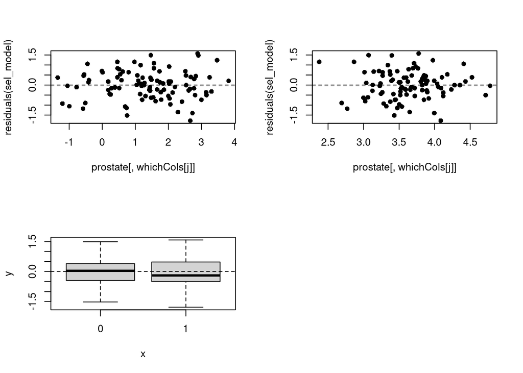

```r
sel_model <- sel_bic_both
whichCols <- names(sel_bic_both$coefficients)[-1]
if(any(whichCols == "svi1")) whichCols[whichCols == "svi1"] <- "svi"
par(mfrow=c(2,ceiling(length(whichCols)/2)),pch=16)
for(j in seq_along(whichCols)){
 plot(prostate[,whichCols[j]], residuals(sel_model))
  abline(h=0,lty=2)
}
```

Next we plot fitted values against the residuals:

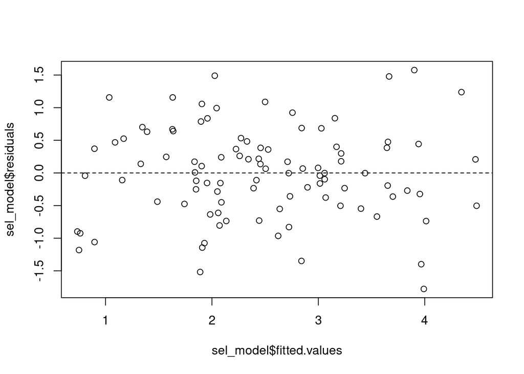

```r
plot(sel_model$fitted.values, sel_model$residuals)
abline(h=0,lty=2)
```

```r
# can also be derived with
# plot(sel_model,which=1)
```

These plots are also useful to identify issues with the homoschedasticity (equal variances) assumption.

For the `sel_bic_both` model there do not seem to be major issues. Let’s now check for normality:

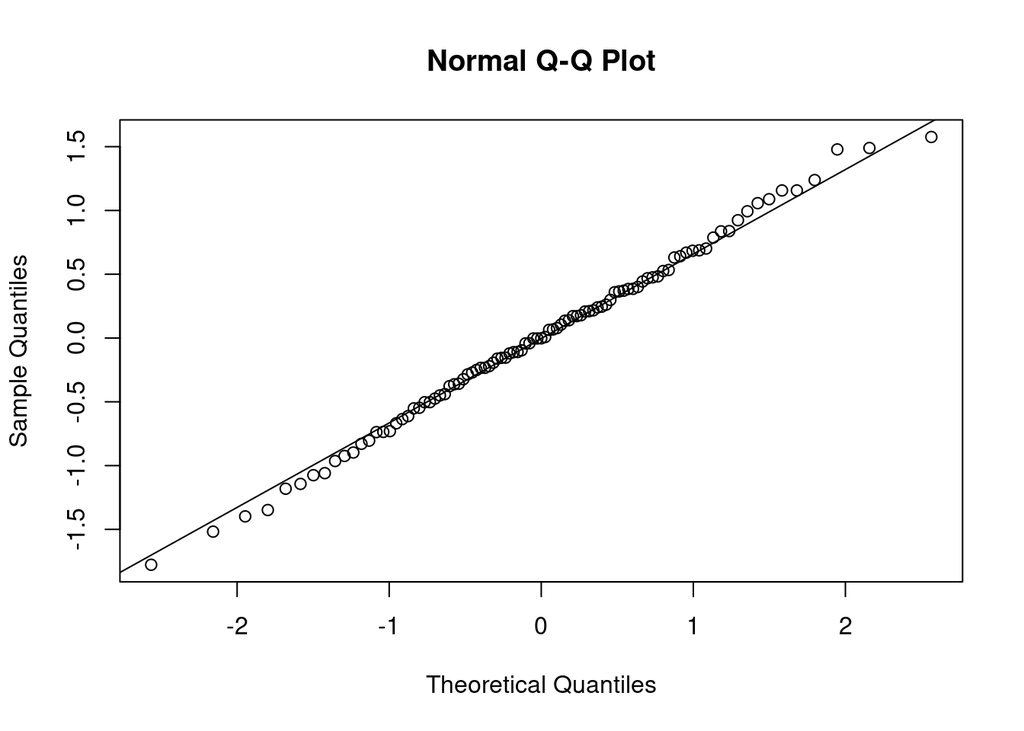

```r
qqnorm(sel_model$residuals)
qqline(sel_model$residuals)
```

```r
# can also be derived with
# plot(sel_model,which=2)
```

The qqplot looks nice, nothing major to report.

Since these are hospital patients which have undergone surgery there is no clear reason why the measurements should be dependent. With the information given we do not know for example if we have several subjects who belong to the same family or have lived in the same area and might have therefore be exposed to similar pollution levels. If the measurements were taken in two different hospitals we might also need to check if patients in one hospital are more similar to each other than to patients in the other hospital. We do not have these information, so we can not have strong arguments against the assumption of independence.

## The qqplot

The qqplot compares the distribution of the residuals to a normal. How is the constructed? The idea is that if the sample was normally-behaved, the sorted sample should be similar to a random sample of size $n$ from normal distribution. But what would a sample of size $n$ from the normal look like? The most “likely” sample we could extract from the normal is the one extracted with probabilities $(1,\ldots,n)/(n+1)$ for which we can compute the quantiles, either from the standard normal of from the normal with mean and standard deviation corresponding to the sample mean and standard deviation:

```r
## empirical quantiles
n <- nrow(sel_model$model)
head(sort(sel_model$residuals))
```

```
##        39         5        47        18         1         7
## -1.777446 -1.517854 -1.398234 -1.348380 -1.181472 -1.143684
```

```r
## theoretical quantiles under the standard normal
head(qnorm(seq(1,n)/(n+1)))
```

```
## [1] -2.318758 -2.045391 -1.871871 -1.741291 -1.635039 -1.544575
```

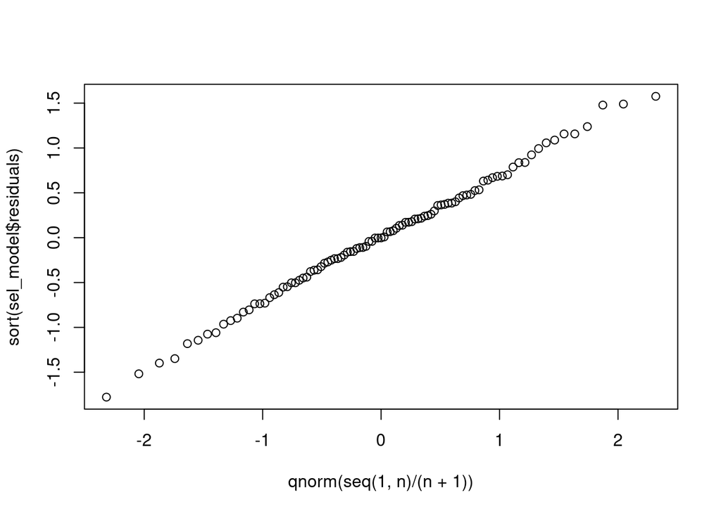

```r
plot(qnorm(seq(1,n)/(n+1)),
     sort(sel_model$residuals))
```

The choice of how to define the probabilities for the theoretical sample can be quite important. The formula to define this is written in the general form as
$$\frac{i-a}{n+1-2a}$$
and referred to as “plotting position” - see `ppoints` for some more information on how R implements this. By default R for larger datasets take plotting positions with $a=0.5$, so:
$$\frac{i-0.5}{n}$$

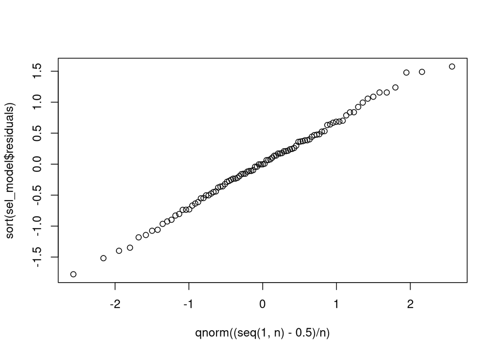

```r
plot(qnorm((seq(1,n)-0.5)/n),
     sort(sel_model$residuals))
```